# DMA - Homework 3

Viet Ba Mai

26 pazdziernika 2016

# Input data

`student-mat` is a .csv file with data regarding alcohol consumption among math course students. 10 first observations of selected columns from the imported table are presented below:

```
##    Dalc studytime age absences failures freetime goout
## 1     1         2  18        6        0        3     4
## 2     1         2  17        4        0        3     3
## 3     2         2  15       10        3        3     2
## 4     1         3  15        2        0        2     2
## 5     1         2  16        4        0        3     2
## 6     1         2  16       10        0        4     2
## 7     1         2  16        0        0        4     4
## 8     1         2  17        6        0        1     4
## 9     1         2  15        0        0        2     2
## 10    1         2  15        0        0        5     1
```

In this homework I will be creating `decision trees` and `random forests`.

# Decision Tree

In order to build a decision tree I will use the `party` library as it is better for visualisation than the traditional `rpart` library.

```r
#install.packages("party")
library(party)
```

```r
student_mat$Dalc <- factor(student_mat$Dalc)
dalcTree <- ctree(Dalc ~ studytime + age + absences + failures + freetime + goout, data = student_mat)
print(dalcTree)
```

```
##
##   Conditional inference tree with 3 terminal nodes
##
## Response:  Dalc
## Inputs:  studytime, age, absences, failures, freetime, goout
## Number of observations:  395
##
## 1) goout <= 3; criterion = 1, statistic = 29.251
##   2)*  weights = 256
## 1) goout > 3
##   3) studytime <= 1; criterion = 0.961, statistic = 14.226
##     4)*  weights = 40
##   3) studytime > 1
##     5)*  weights = 99
```

```r
summary(dalcTree)
```

```
##     Length      Class       Mode
##          1 BinaryTree         S4
```

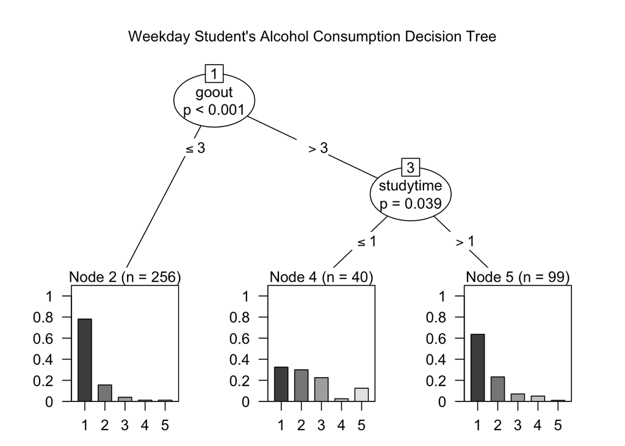

```r
plot(dalcTree, main="Weekday Student's Alcohol Consumption Decision Tree")
```

We can observe that the variables `goout` and `studytime` were chosen as the ones that strongly affect the response with their p-values being very small - usually it is compared to a cutoff value `0.05` and if it’s smaller then the `null hypothesis` is rejected which suggests that these values are statistically `significant`.

From the plot above we can see that students which go out with friends less often (less or equal to 3) have a much higher ratio of consuming alcohol only **one** day (class 1) during workdays to more than one (2-5).

In case when the `goout` value is higher than 3, the decision is dependent on the weekly hours of studying (`studytime`).

# Random Forest

Forest is a set of trees which contain a `vote` allowing us to find an appropriate result. We will test it on different values of correlation between trees to find and optimal one by observing the OOB error. Different correlation can be achieved by selecting random input variables.

In order to do that I will make use of the `randomForest` library.

```r
#install.packages("randomForest")
library(randomForest)
```

## Random forest on the same variables

```r
ffit <- randomForest(Dalc ~ ., data=student_mat, importance = TRUE, prox=TRUE)
head(predict(ffit, type="prob"))
```

```
##           1          2           3           4           5
## 1 0.9086022 0.08602151 0.005376344 0.000000000 0.000000000
## 2 0.9222798 0.05699482 0.010362694 0.010362694 0.000000000
## 3 0.5645161 0.31182796 0.069892473 0.043010753 0.010752688
## 4 0.9473684 0.04736842 0.000000000 0.005263158 0.000000000
## 5 0.8287293 0.14364641 0.005524862 0.016574586 0.005524862
## 6 0.9153439 0.04761905 0.026455026 0.005291005 0.005291005
```

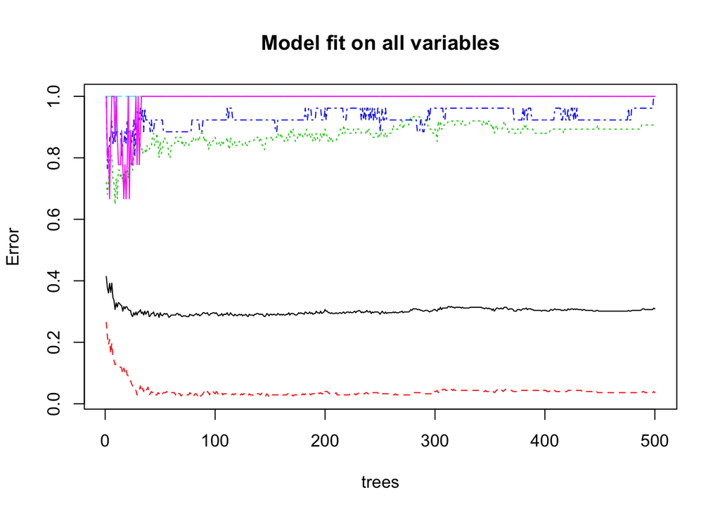

```r
plot(ffit, main="Model fit on all variables")
```

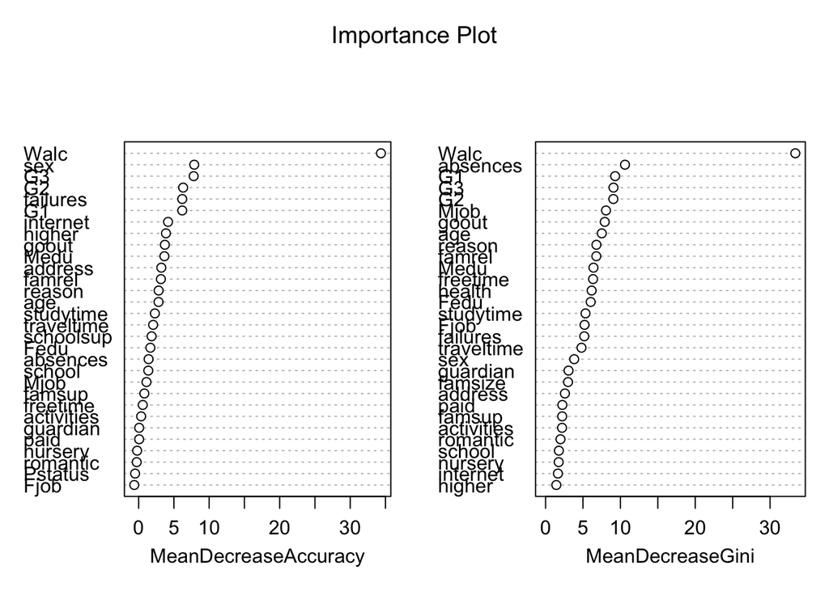

```r
varImpPlot(ffit, main="Importance Plot")
```

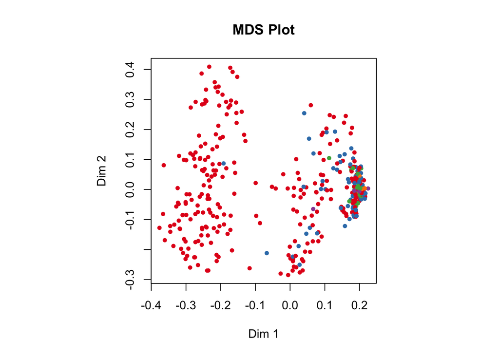

```r
MDSplot(ffit, student_mat$Dalc, main="MDS Plot")
```

Based on the importance plot and the variable importance we will select the variables for further testing.

## Mean Decrease in Accuracy

Mean Decrease in Accuracy is a measure of how much a model fit would decrease when a given variable is changed, or removed. We will test 3 selected variables that have larger values of `MeanDecreaseAccuracy`.

```r
ffit2 <- randomForest(Dalc ~ G1 + sex + failures, data=student_mat, importance = TRUE)
head(predict(ffit2, type="prob"))
```

```
##           1           2          3 4 5
## 1 1.0000000 0.000000000 0.00000000 0 0
## 2 1.0000000 0.000000000 0.00000000 0 0
## 3 0.8000000 0.189743590 0.01025641 0 0
## 4 1.0000000 0.000000000 0.00000000 0 0
## 5 0.9786096 0.021390374 0.00000000 0 0
## 6 0.9941860 0.005813953 0.00000000 0 0
```

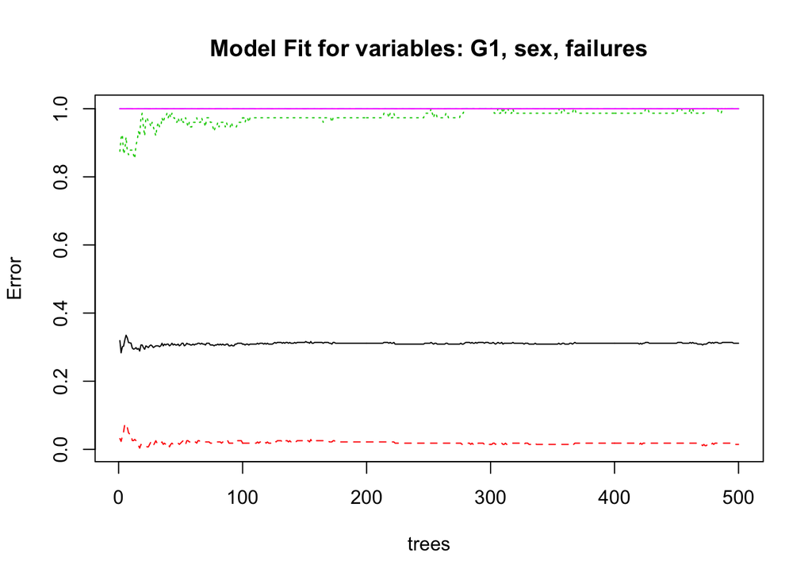

```r
plot(ffit2, main="Model Fit for variables: G1, sex, failures")
```

## Mean Decrease in Gini

Gini is a measure of node purity that is used when calculating splits. We will test 3 selected variables that have larger values of `MeanDecreaseGini`.

```r
ffit3 <- randomForest(Dalc ~ absences + goout + age, data=student_mat, importance = TRUE)
head(predict(ffit3, type="prob"))
```

```
##           1          2           3          4 5
## 1 0.9119171 0.08290155 0.005181347 0.00000000 0
## 2 1.0000000 0.00000000 0.000000000 0.00000000 0
## 3 0.9554455 0.02970297 0.004950495 0.00990099 0
## 4 1.0000000 0.00000000 0.000000000 0.00000000 0
## 5 1.0000000 0.00000000 0.000000000 0.00000000 0
## 6 0.8988764 0.05617978 0.016853933 0.02808989 0
```

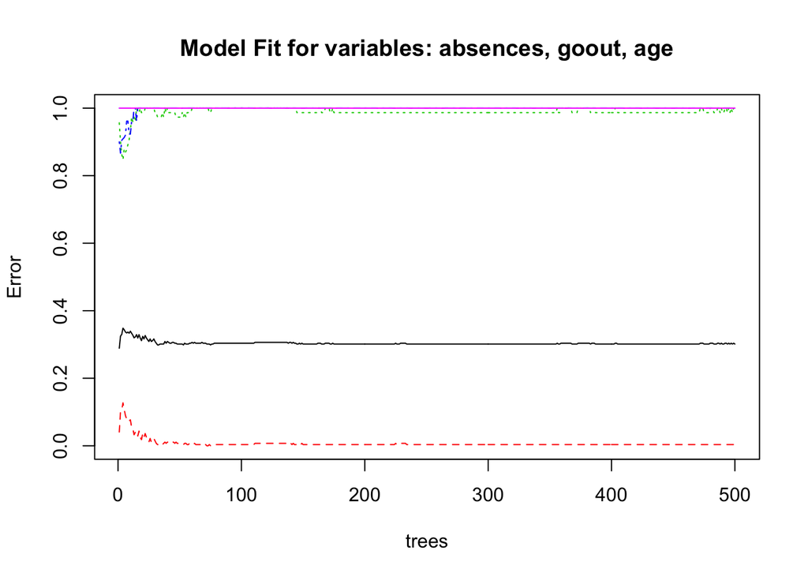

```r
plot(ffit3, main="Model Fit for variables: absences, goout, age")
```

## Randomly chosen variables

I decided to pick variables not used before in this section.

```r
ffit4 <- randomForest(Dalc ~ famsize + traveltime + activities, data=student_mat, importance = TRUE)
head(predict(ffit4, type="prob"))
```

```
##   1 2 3 4 5
## 1 1 0 0 0 0
## 2 1 0 0 0 0
## 3 1 0 0 0 0
## 4 1 0 0 0 0
## 5 1 0 0 0 0
## 6 1 0 0 0 0
```

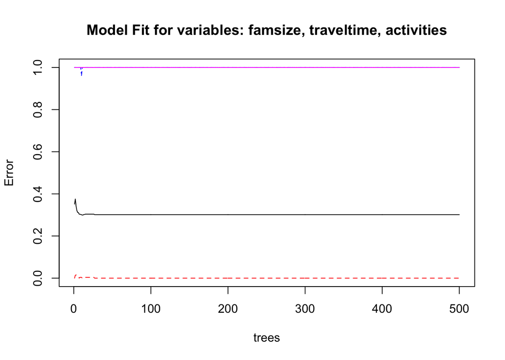

```r
plot(ffit4, main="Model Fit for variables: famsize, traveltime, activities")
```

#Performance comparison

```r
tab <- table(real = student_mat$Dalc, predicted = predict(dalcTree))
tab
```

```
##     predicted
## real   1   2   3   4   5
##    1 276   0   0   0   0
##    2  75   0   0   0   0
##    3  26   0   0   0   0
##    4   9   0   0   0   0
##    5   9   0   0   0   0
```

```r
sum(diag(tab)) / sum(tab)
```

```
## [1] 0.6987342
```

```r
print(ffit)
```

```
##
## Call:
##  randomForest(formula = Dalc ~ ., data = student_mat, importance = TRUE,      prox = TRUE)
##                Type of random forest: classification
##                      Number of trees: 500
## No. of variables tried at each split: 5
##
##         OOB estimate of  error rate: 30.89%
## Confusion matrix:
##     1  2 3 4 5 class.error
## 1 266 10 0 0 0  0.03623188
## 2  67  7 1 0 0  0.90666667
## 3  18  7 0 0 1  1.00000000
## 4   7  1 1 0 0  1.00000000
## 5   5  3 1 0 0  1.00000000
```

```r
print(ffit2)
```

```
##
## Call:
##  randomForest(formula = Dalc ~ G1 + sex + failures, data = student_mat,      importance = TRUE)
##                Type of random forest: classification
##                      Number of trees: 500
## No. of variables tried at each split: 1
##
##         OOB estimate of  error rate: 31.14%
## Confusion matrix:
##     1 2 3 4 5 class.error
## 1 272 4 0 0 0  0.01449275
## 2  75 0 0 0 0  1.00000000
## 3  26 0 0 0 0  1.00000000
## 4   8 1 0 0 0  1.00000000
## 5   8 1 0 0 0  1.00000000
```

```r
print(ffit3)
```

```
##
## Call:
##  randomForest(formula = Dalc ~ absences + goout + age, data = student_mat,      importance = TRUE)
##                Type of random forest: classification
##                      Number of trees: 500
## No. of variables tried at each split: 1
##
##         OOB estimate of  error rate: 30.13%
## Confusion matrix:
##     1 2 3 4 5 class.error
## 1 276 0 0 0 0           0
## 2  75 0 0 0 0           1
## 3  26 0 0 0 0           1
## 4   9 0 0 0 0           1
## 5   8 0 1 0 0           1
```

```r
print(ffit4)
```

```
##
## Call:
##  randomForest(formula = Dalc ~ famsize + traveltime + activities,      data = student_mat, importance = TRUE)
##                Type of random forest: classification
##                      Number of trees: 500
## No. of variables tried at each split: 1
##
##         OOB estimate of  error rate: 30.13%
## Confusion matrix:
##     1 2 3 4 5 class.error
## 1 276 0 0 0 0           0
## 2  75 0 0 0 0           1
## 3  26 0 0 0 0           1
## 4   9 0 0 0 0           1
## 5   9 0 0 0 0           1
```

# Conclusions

The `OOB estimate of error rate` is very close for tested variable sets when using the forest tree. There is randomness included so each execution results in slightly different values for OOB, but they all were each time around `30%`, even for the randomly chosen variables. It is hard to distinguish the optimal `m` (variable set) for this case.